# task4

Edgaras Petrauskas

Monday, March 14, 2016

Aplanke task4 yra duomenų failas, kuriame rasite nekilnojamo turto (o tiksliau gyvenamųjų butų) kainas ir kaikurias jų charakteristikas. Jūsų užduotis yra atlikti išsamią tiesinę regresiją. Lygtis reikalinga prekyboms agentams, kad geriau suprastų kokią įtaką skirtingos charakteristikos daro galutinei kainai.

Nuskaitomi duomenys ir susidaromas bendras duomenų vaizdas.

```r
library(car)
library(knitr)
setwd("C:/Users/Vartotojas/Desktop/Econometrics/task4")
duom <- read.csv2("data.csv")
attach(duom)
str(duom)
```

```
## 'data.frame':    254 obs. of  6 variables:
##  $ kaina                    : int  55800 52700 53400 71600 46700 61200 53000 43300 53000 52600 ...
##  $ plotas                   : int  73 73 66 86 54 75 63 54 67 60 ...
##  $ aukstas                  : int  8 1 6 2 5 4 2 7 2 6 ...
##  $ garsoIzoliacija          : num  7.82 11.18 8 10.42 7 ...
##  $ silumosLaidumas          : num  7.61 10.99 8.46 10.48 6.69 ...
##  $ atstumasIkiPrekybosCentro: num  0.8085 0.0859 0.688 0.7264 1.1449 ...
```

```r
kable(head(duom), digits = 2)
```

| kaina | plotas | aukstas | garsoIzoliacija | silumosLaidumas | atstumasIkiPrekybosCentro |
| --- | --- | --- | --- | --- | --- |
| 55800 | 73 | 8 | 7.82 | 7.61 | 0.81 |
| 52700 | 73 | 1 | 11.18 | 10.99 | 0.09 |
| 53400 | 66 | 6 | 8.00 | 8.46 | 0.69 |
| 71600 | 86 | 2 | 10.42 | 10.48 | 0.73 |
| 46700 | 54 | 5 | 7.00 | 6.69 | 1.14 |
| 61200 | 75 | 4 | 11.19 | 10.29 | 0.89 |

Pirmiausia ieškosime duomenų išskirčių. Grafiškai:

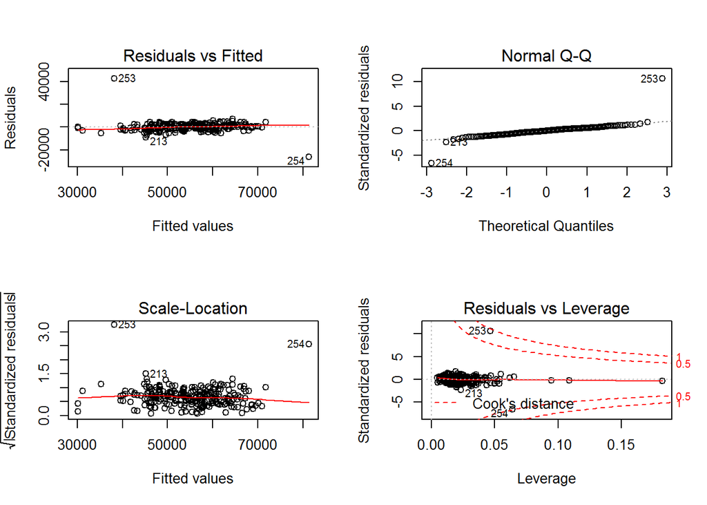

```r
mod1.lm <- lm(kaina ~ plotas + aukstas + garsoIzoliacija + silumosLaidumas + atstumasIkiPrekybosCentro, data = duom)  # pradinis nepakeistas modelis
par(mfrow=c(2,2))
plot(mod1.lm)
```

Iš grafikų matosi įtartinos 253 ir 254 reikšmės, pasitikslinsime outlierTest pagalba.

```r
outlierTest(mod1.lm)
```

```
##      rstudent unadjusted p-value Bonferonni p
## 253 14.334591         2.5467e-34   6.4687e-32
## 254 -7.221533         6.3423e-12   1.6110e-09
```

```r
duom1 <- duom[-c(253, 254),]  # išskirtis pašaliname
```

Reikia nustatyti, ar yra x’sų priklausomybė su kitais x’sais. Žiūrėsime koreliaciją tarp jų.

```r
cor(duom1) # iš koreliacijų maatricos matosi, kad šilumos laidumas ir garso izoliacija yra stipriai koreliuoti (koeficientas net 0.95)
```

```
##                                kaina     plotas      aukstas
## kaina                     1.00000000 0.93239026  0.104757604
## plotas                    0.93239026 1.00000000  0.040497076
## aukstas                   0.10475760 0.04049708  1.000000000
## garsoIzoliacija           0.25702119 0.06181567 -0.140198539
## silumosLaidumas           0.24889159 0.05822615 -0.123061633
## atstumasIkiPrekybosCentro 0.09610163 0.07713012 -0.006846884
##                           garsoIzoliacija silumosLaidumas
## kaina                          0.25702119      0.24889159
## plotas                         0.06181567      0.05822615
## aukstas                       -0.14019854     -0.12306163
## garsoIzoliacija                1.00000000      0.95415818
## silumosLaidumas                0.95415818      1.00000000
## atstumasIkiPrekybosCentro      0.03403702      0.03272599
##                           atstumasIkiPrekybosCentro
## kaina                                   0.096101627
## plotas                                  0.077130121
## aukstas                                -0.006846884
## garsoIzoliacija                         0.034037018
## silumosLaidumas                         0.032725992
## atstumasIkiPrekybosCentro               1.000000000
```

```r
vif(mod1.lm) # šilumos laidumo ir garso izoliacijos VIF'ai taip pat yra dideli (>10)
```

```
##                    plotas                   aukstas
##                  1.012227                  1.022754
##           garsoIzoliacija           silumosLaidumas
##                 11.072904                 11.029024
## atstumasIkiPrekybosCentro
##                  1.006391
```

Vadinasi, pradiniame modelyje yra multikolinearumo problema. Modelyje prasmingiau būtų naudoti šilumos laidumą, todėl iš jo išmesime garso izoliaciją.

```r
duom2 <- duom1[,-4]
```

Patikrinsime naujo modelio be garso izoliacijos heteroskedastiškumą.

```r
mod2.lm <- lm(kaina ~ plotas + aukstas + silumosLaidumas + atstumasIkiPrekybosCentro, data = duom2)
kable(summary(mod2.lm)$coef,digits=2)
```

|  | Estimate | Std. Error | t value | Pr(>\|t\|) |
| --- | --- | --- | --- | --- |
| (Intercept) | 7966.67 | 977.86 | 8.15 | 0.00 |
| plotas | 599.37 | 12.13 | 49.41 | 0.00 |
| aukstas | 318.66 | 63.49 | 5.02 | 0.00 |
| silumosLaidumas | 527.45 | 47.52 | 11.10 | 0.00 |
| atstumasIkiPrekybosCentro | 85.45 | 81.38 | 1.05 | 0.29 |

Kadangi atstumo iki prekybos centro p-value 0.295 > 0.05, šis narys yra statistiškai nereikšmingas, todėl iš modelio jį išmesime.

```r
mod3.lm <- lm(kaina ~ plotas + aukstas + silumosLaidumas, data = duom2)
kable(summary(mod3.lm)$coef,digits=2)
```

|  | Estimate | Std. Error | t value | Pr(>\|t\|) |
| --- | --- | --- | --- | --- |
| (Intercept) | 8035.80 | 975.85 | 8.23 | 0 |
| plotas | 600.33 | 12.10 | 49.62 | 0 |
| aukstas | 318.23 | 63.50 | 5.01 | 0 |
| silumosLaidumas | 528.82 | 47.51 | 11.13 | 0 |

Tikriname heteroskedatstiškumą ir VIF.

```r
ncvTest(mod3.lm) # p = 0.07 > 0.05, vadinasi modelis homoskedastiškas
```

```
## Non-constant Variance Score Test
## Variance formula: ~ fitted.values
## Chisquare = 3.218568    Df = 1     p = 0.0728073
```

```r
vif(mod3.lm)     # VIF maži - viskas gerai
```

```
##          plotas         aukstas silumosLaidumas
##        1.005730        1.017733        1.019520
```

Galima numanyti, kad buto aukštą geriau naudoti kaip žyminį kintamąjį (dummy variable). Pavyzdžiui, kainų skirtumas tarp 1 ir 2 aukštų turėtų būti didesnis nei tarp 7 ir 8 aukštų.

```r
aukstaszym <- factor(duom2$aukstas)
is.factor(aukstaszym)
```

```
## [1] TRUE
```

```r
aukstaszym
```

```
##   [1] 8 1 6 2 5 4 2 7 2 6 4 3 1 3 2 5 2 7 9 1 4 3 5 2 2 8 1 7 3 5 7 7 2 9 6
##  [36] 1 7 6 1 2 2 9 6 1 4 2 6 4 6 1 3 4 1 1 8 2 5 8 6 8 4 3 8 4 7 2 4 5 2 6
##  [71] 4 5 2 2 8 9 7 9 8 4 8 1 2 5 2 5 3 1 3 7 7 5 4 3 8 3 9 8 8 8 1 2 8 6 3
## [106] 2 9 6 5 7 9 3 5 5 6 9 1 8 6 4 2 8 6 1 8 4 7 7 7 1 2 1 3 4 4 7 9 5 9 2
## [141] 5 3 3 1 8 3 3 1 4 6 2 4 3 4 4 3 4 2 7 4 3 8 4 7 9 5 4 6 3 1 2 8 5 9 7
## [176] 1 6 7 3 9 5 9 4 8 1 9 7 3 7 1 4 7 6 5 2 9 6 8 3 9 5 5 9 6 3 3 7 3 7 1
## [211] 5 2 1 9 9 5 3 5 4 2 4 3 7 6 1 6 7 4 7 9 5 9 3 5 1 8 8 4 3 9 6 4 2 5 2
## [246] 6 8 3 6 5 9 9
## Levels: 1 2 3 4 5 6 7 8 9
```

```r
mod4.lm <- lm(kaina ~ plotas + aukstaszym + silumosLaidumas, data = duom2)
kable(summary(mod4.lm)$coef,digits=2)
```

|  | Estimate | Std. Error | t value | Pr(>\|t\|) |
| --- | --- | --- | --- | --- |
| (Intercept) | 4784.01 | 844.28 | 5.67 | 0 |
| plotas | 599.10 | 9.91 | 60.48 | 0 |
| aukstaszym2 | 5515.66 | 546.94 | 10.08 | 0 |
| aukstaszym3 | 5198.13 | 542.87 | 9.58 | 0 |
| aukstaszym4 | 6023.11 | 547.44 | 11.00 | 0 |
| aukstaszym5 | 5126.61 | 560.23 | 9.15 | 0 |
| aukstaszym6 | 5735.07 | 577.05 | 9.94 | 0 |
| aukstaszym7 | 5249.70 | 567.22 | 9.26 | 0 |
| aukstaszym8 | 5656.35 | 580.02 | 9.75 | 0 |
| aukstaszym9 | 4990.79 | 572.54 | 8.72 | 0 |
| silumosLaidumas | 530.90 | 38.87 | 13.66 | 0 |

Kadangi lygtyje pirmas aukštas yra bazinis, tai vien tai, kad butas nėra pirmame aukšte, ženkliai kelia jo kainą (maždaug nuo 5000 iki 6000 kainos vnt.). Matomas ryškus skirtumas tarp pirmo ir likusiųjų aukštų kainų, todėl nepirmus aukštus modelyje galima neišskaidyti.

```r
aukstaslik = as.numeric(duom2$aukstas!=1)
aukstaslik  # reikšmė 0, kai pirmas aukštas
```

```
##   [1] 1 0 1 1 1 1 1 1 1 1 1 1 0 1 1 1 1 1 1 0 1 1 1 1 1 1 0 1 1 1 1 1 1 1 1
##  [36] 0 1 1 0 1 1 1 1 0 1 1 1 1 1 0 1 1 0 0 1 1 1 1 1 1 1 1 1 1 1 1 1 1 1 1
##  [71] 1 1 1 1 1 1 1 1 1 1 1 0 1 1 1 1 1 0 1 1 1 1 1 1 1 1 1 1 1 1 0 1 1 1 1
## [106] 1 1 1 1 1 1 1 1 1 1 1 0 1 1 1 1 1 1 0 1 1 1 1 1 0 1 0 1 1 1 1 1 1 1 1
## [141] 1 1 1 0 1 1 1 0 1 1 1 1 1 1 1 1 1 1 1 1 1 1 1 1 1 1 1 1 1 0 1 1 1 1 1
## [176] 0 1 1 1 1 1 1 1 1 0 1 1 1 1 0 1 1 1 1 1 1 1 1 1 1 1 1 1 1 1 1 1 1 1 0
## [211] 1 1 0 1 1 1 1 1 1 1 1 1 1 1 0 1 1 1 1 1 1 1 1 1 0 1 1 1 1 1 1 1 1 1 1
## [246] 1 1 1 1 1 1 1
```

```r
mod5.lm <- lm(kaina ~ plotas + aukstaslik + silumosLaidumas, data = duom2)
kable(summary(mod5.lm)$coef,digits=2) # visi kintamieji reikšmingi
```

|  | Estimate | Std. Error | t value | Pr(>\|t\|) |
| --- | --- | --- | --- | --- |
| (Intercept) | 4795.47 | 837.81 | 5.72 | 0 |
| plotas | 598.84 | 9.83 | 60.94 | 0 |
| aukstaslik | 5440.16 | 422.84 | 12.87 | 0 |
| silumosLaidumas | 531.42 | 38.39 | 13.84 | 0 |

```r
AIC(mod1.lm)
```

```
## [1] 4958.962
```

```r
AIC(mod2.lm)
```

```
## [1] 4674.872
```

```r
AIC(mod3.lm)
```

```
## [1] 4673.994
```

```r
AIC(mod4.lm)
```

```
## [1] 4577.481
```

```r
AIC(mod5.lm) # pagal AIC paskutinis modelis yra tiksliausias
```

```
## [1] 4569.454
```

```r
ncvTest(mod5.lm) # p = 0.79 > 0.05, vadinasi modelis homoskedastiškas
```

```
## Non-constant Variance Score Test
## Variance formula: ~ fitted.values
## Chisquare = 0.06839552    Df = 1     p = 0.7936874
```

```r
vif(mod5.lm)     # VIF maži - viskas gerai
```

```
##          plotas      aukstaslik silumosLaidumas
##        1.004627        1.005329        1.007775
```

Reikia įsitikinti, ar modelio paklaidos yra normaliosios.

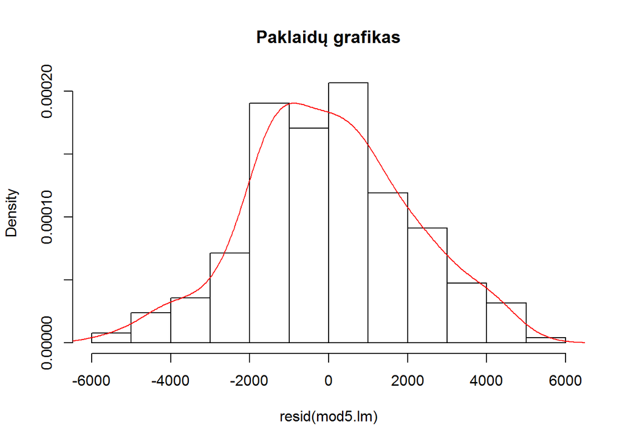

```r
par(mfrow=c(1,1))
hist(resid(mod5.lm), probability = TRUE, main = "Paklaidų grafikas")  # paklaidų grafikas panašus į normalųjį
lines(density(resid(mod5.lm)), col = "red")
```

```r
res <- as.vector(mod5.lm$residuals)
shapiro.test(res)  # p-value = 0.3798 > 0.05, vadinasi liekanos normalios
```

```
##
##  Shapiro-Wilk normality test
##
## data:  res
## W = 0.9938, p-value = 0.3798
```

```r
kable(summary(mod5.lm)$coef,digits=2)
```

|  | Estimate | Std. Error | t value | Pr(>\|t\|) |
| --- | --- | --- | --- | --- |
| (Intercept) | 4795.47 | 837.81 | 5.72 | 0 |
| plotas | 598.84 | 9.83 | 60.94 | 0 |
| aukstaslik | 5440.16 | 422.84 | 12.87 | 0 |
| silumosLaidumas | 531.42 | 38.39 | 13.84 | 0 |

Taigi, skirtingų charakteristikų darommą įtaką galutinei kainai geriausiai prognozuoja modelis mod5.lm